# Basics of PYTHON

- A Python program is divided into a number of logical lines.
- Logical lines -

The end of a logical line is represented by the token NEWLIN. A logical line is constructed from one or more physical lines by following the explicit or implicit line joining rules.

- Physical lines -

A physical line is a sequence of characters terminated by an end-of-line sequence

- Comments - A comment starts with a hash character (#) that is not part of a string literal, and ends at the end of the physical line. Comments are ignored by the syntax.

### Explicit line joining -

Two or more physical lines may be joined intoa single logical lines using backslash characters (\ ), as follows: when a physical line ends in backslash that is not part of a string litera or comment.

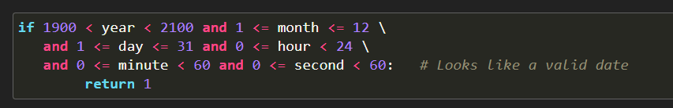

### Implicit line joining -

- Expressions in parentheses, square brackets or curly braces can be split over more than one physical line without using backslashes.

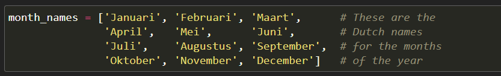

### Blank lines

- A logical line that contains only spaces, tabs, formfeeds and possibly a comment, is ignored.
- During interactive input of statements, handling of a blank line may differ depending on the implementation of the read-eval-print loop.

# Indentation - Important in Python for the Successful Execution of Code.

- Leading whitespace (spaces and tabs) at the beginning of a logical line is used to compute the indentation level of the line, which in turn is used to determine the grouping of statements.
- Tabs are replaced (from left to right) by one to eight spaces such that the total number of characters up to and including the replacement is a multiple of eight (this is intended to be the same rule as used by Unix)
- TabError is raised when indentation contains an inconsistent use of tabs and spaces. This is a subclass of IndentationError.

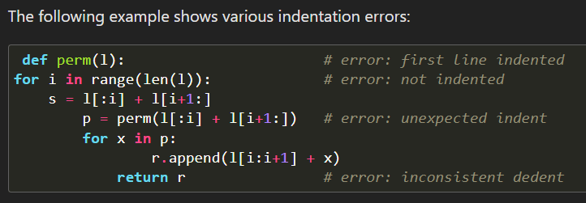

## Identifiers

- the valid characters include the uppercase and lowercase letters A through Z,
- the underscore _ and, ##Only special character allowed
- except for the first character, the digits 0 through 9 ## Not as a first character
- Identifiers are unlimited in length. ## No length limit
- Case is significant. ## Case Sensitive

# Keywords

The following identifiers are used as reserved words, or keywords of the language, and cannot be used as ordinary identifiers. They must be spelled exactly as written here

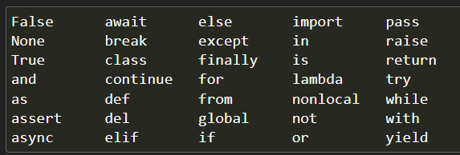

## Soft Keywords -

- Some identifiers are only reserved under specific contexts. These are known as soft keywords.
- The identifiers match, case, type and _ can syntactically act as keywords in certain contexts, but this distinction is done at the parser level, not when tokenizing.
- match, case, and _ are used in the match statement. type is used in the type statement.

## Escape sequences

Unless an 'r' or 'R' prefix is present, escape sequences in string and bytes literals are interpreted according to rules similar to those used by Standard C. The recognized escape sequences are

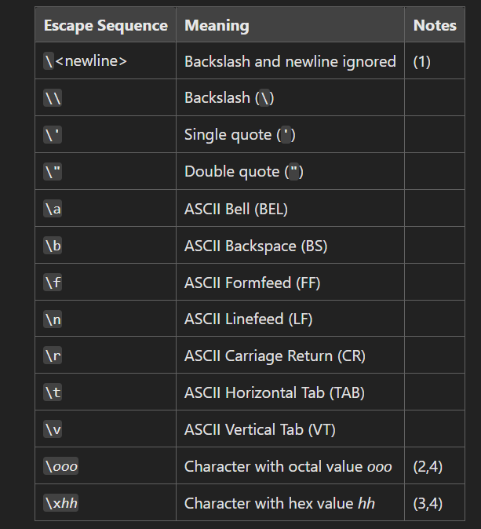

## f-strings -

- A formatted string literal or f-string is a string literal that is prefixed with 'f' or 'F'. These strings may contain replacement fields, which are expressions delimited by curly braces {}. While other string literals always have a constant value, formatted strings are really expressions evaluated at run time.

## Literals -

Literals are notations for constant values of some built-in types

### String and Bytes literals -

- Both types of literals can be enclosed in matching single quotes (') or double quotes ("). They can also be enclosed in matching groups of three single or double quotes (these are generally referred to as triple-quoted strings).
- Bytes literals are always prefixed with 'b' or 'B'; they produce an instance of the bytes type instead of the str type. They may only contain ASCII characters; bytes with a numeric value of 128 or greater must be expressed with escapes.

Both string and bytes literals may optionally be prefixed with a letter 'r' or 'R'; such constructs are called raw string literals and raw bytes literals respectively and treat backslashes as literal characters. As a result, in raw string literals, '\U' and '\u' escapes are not treated speciay

- A string literal with 'f' or 'F' in its prefix is a formatted string literal; see f-strings. The 'f' may be combined with 'r', but not with 'b' or 'u', therefore raw formatted strings are possible, but formatted bytes literals are not.

In triple-quoted literals, unescaped newlines and quotes are allowed (and are retained), except that three unescaped quotes in a row terminate the literal. (A “quote” is the character used to open the literal, i.e. either ' or ".)y..

### Numeric literals -

- There are three types of numeric literals: integers, floating-point numbers, and imaginary numbers. There are no complex literals (complex numbers can be formed by adding a real number and an imaginary number).
- Note that numeric literals do not include a sign; a phrase like -1 is actually an expression composed of the unary operator ‘-’ and the literal 1.

[figure not shown]